# Structural Equation Models 2019

## Week 6

First let us import the data file in R and prepare it for the excercises.

### Exercise 6.1

Let us specify and establish a well-fitting and parsimonious baseline model for the calibration group. We begin with the hypothesized model:

### Hypothesized model:

```r
model <- '
RA  =~ ROLEA1 + ROLEA2
RC  =~ ROLEC1 + ROLEC2
WO  =~ WORK1 + WORK2
CC  =~ CCLIM1 + CCLIM2 + CCLIM3 + CCLIM4
DM  =~ DEC1 + DEC2
SS  =~ SSUP1 + SSUP2
PS  =~ PSUP1 + PSUP2
SE  =~ SELF1 + SELF2 + SELF3
ELC  =~ ELC1 + ELC2 + ELC3 + ELC4 + ELC5
EE  =~ EE1 + EE2 + EE3
DP  =~ DP1 + DP2
PA  =~ PA1 + PA2 + PA3

SE ~ DM + SS + PS
ELC ~ DM
EE ~ RC + WO + CC
DP ~ RC + EE
PA ~ RA + SE + ELC + EE + DP
'

fit <- sem(model, data = E1, estimator="MLM")
```

First we draw the hypothesized model in Figure 1.

The factor names are as follows:

- RA = Role ambiguity
- RC = Role conflict
- WO = Work overload
- CC = Classroom climate
- DM = Decision-making
- SS = Superior support
- PS = Peer support
- SE = Self-esteem
- ELC = External locus of control
- EE = Emotional exhaustion
- DP = Depersonalization
- PA = Personal accomplishment

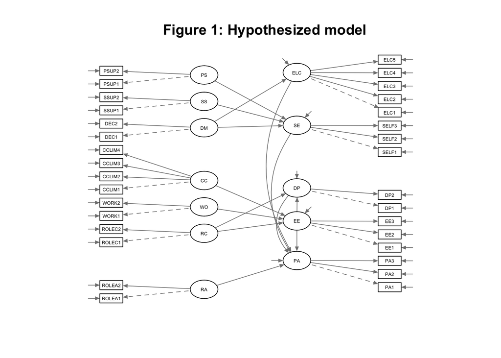

Let us view the standardized covariance estimates exceeding the value of 1:

Covariance estimates of the initial model that exceed 1

| Item/Factor | op | Item/Factor | Est.covariance | Std.covariance | pvalue |
| --- | --- | --- | --- | --- | --- |
| EE | ~~ | EE | 3.457 | 2.371 | 0.533 |
| RC | ~~ | WO | 0.674 | 1.005 | 0.000 |

Table 1 shows that the standardized covariance of factors RC and WO is 1.005, which means the factors are representing the same construct. Therefore we can combine them. Let us specify a new model and view a graph of the model:

### Modified model:

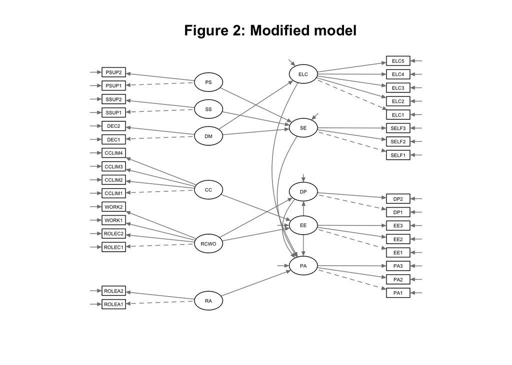

Let us view the fit measures of the modified model:

Fit indices (Modified model)

| Model | Chi.square | Df | p.value | CFI | TLI | RMSEA | SRMR |
| --- | --- | --- | --- | --- | --- | --- | --- |
| Modified | 942.1924 | 436 | 0 | 0.944 | 0.936 | 0.046 | 0.062 |

The fit indices indicate that the fit is not good - let us view modification indices:

```
##      lhs op  rhs     mi    epc sepc.lv sepc.all sepc.nox
## 973  ELC  ~ RCWO 51.043  0.281   0.503    0.503    0.503
## 892  EE1 ~~  EE2 46.273  0.297   0.297    0.876    0.876
## 141 RCWO =~ DEC2 44.663  0.668   0.504    0.405    0.405
## 231   SS =~ DEC2 40.963  1.043   1.139    0.917    0.917
## 971  ELC  ~   SS 39.419  0.384   0.994    0.994    0.994
## 421   PA =~  EE3 38.198 -0.356  -0.249   -0.184   -0.184
```

According to MI’s we should refine the model by adding ELC ~ RCWO. Let us do that:

### Modified model 2:

Fit indices (Modified models)

| Model | Chi.square | Df | p.value | CFI | TLI | RMSEA | SRMR |
| --- | --- | --- | --- | --- | --- | --- | --- |
| Modified | 942.1924 | 436 | 0 | 0.944 | 0.936 | 0.046 | 0.062 |
| Modified 2 | 894.6600 | 435 | 0 | 0.949 | 0.942 | 0.044 | 0.052 |

The fit improved a lot, but we can still refine the model. Let us print the modification indices:

```
##     lhs op rhs     mi    epc sepc.lv sepc.all sepc.nox
## 893 EE1 ~~ EE2 48.193  0.304   0.304    0.894    0.894
## 422  PA =~ EE3 37.738 -0.354  -0.249   -0.183   -0.183
```

The highest MI value suggests that in the next step we should allow the residual covariance between EE1 and EE2:

### Modified model 3:

Fit indices (Modified models)

| Model | Chi.square | Df | p.value | CFI | TLI | RMSEA | SRMR |
| --- | --- | --- | --- | --- | --- | --- | --- |
| Modified | 942.1924 | 436 | 0 | 0.944 | 0.936 | 0.046 | 0.062 |
| Modified 2 | 894.6600 | 435 | 0 | 0.949 | 0.942 | 0.044 | 0.052 |
| Modified 3 | 856.4721 | 434 | 0 | 0.954 | 0.947 | 0.042 | 0.049 |

The model fit seems quite good at this round. Let us view the MI´s:

```
## [1] lhs      op       rhs      mi       epc      sepc.lv  sepc.all sepc.nox
## <0 rows> (or 0-length row.names)
```

There are no MI values larger than 30.

Standardized estimates

| Factor | op | Factor | Beta | p-value |
| --- | --- | --- | --- | --- |
| SE | ~ | DM | 2.256 | 0.003 |
| SE | ~ | SS | -1.772 | 0.007 |
| SE | ~ | PS | -0.226 | 0.239 |
| ELC | ~ | DM | -0.086 | 0.167 |
| ELC | ~ | RCWO | 0.498 | 0.000 |
| EE | ~ | RCWO | 0.577 | 0.000 |
| EE | ~ | CC | -0.213 | 0.000 |
| DP | ~ | RCWO | 0.066 | 0.345 |
| DP | ~ | EE | 0.620 | 0.000 |
| PA | ~ | RA | -0.104 | 0.166 |
| PA | ~ | SE | 0.154 | 0.006 |
| PA | ~ | ELC | -0.034 | 0.535 |
| PA | ~ | EE | -0.180 | 0.016 |
| PA | ~ | DP | -0.293 | 0.001 |

There are five statistically non-significant parameters that can be deleted from the model. They are SE ~ PS, ELC ~ DM, DP ~ RCWO, PA ~ RA and PA ~ ELC.

### Modified model 4:

Fit indices (Modified models)

| Model | Chi.square | Df | p.value | CFI | TLI | RMSEA | SRMR |
| --- | --- | --- | --- | --- | --- | --- | --- |
| Modified | 942.1924 | 436 | 0 | 0.944 | 0.936 | 0.046 | 0.062 |
| Modified 2 | 894.6600 | 435 | 0 | 0.949 | 0.942 | 0.044 | 0.052 |
| Modified 3 | 856.4721 | 434 | 0 | 0.954 | 0.947 | 0.042 | 0.049 |
| Modified 4 | 863.2885 | 438 | 0 | 0.953 | 0.947 | 0.042 | 0.052 |

The model fit did not improve, but we got rid of unnecessary non-significant factors. Now there are factors RA (Role ambiguity) and PS (Peer support) that are not related to other factors, so they can be removed from the model in the next step.

### Modified model 5:

Fit indices (Modified models)

| Model | Chi.square | Df | p.value | CFI | TLI | RMSEA | SRMR |
| --- | --- | --- | --- | --- | --- | --- | --- |
| Modified | 942.1924 | 436 | 0 | 0.944 | 0.936 | 0.046 | 0.062 |
| Modified 2 | 894.6600 | 435 | 0 | 0.949 | 0.942 | 0.044 | 0.052 |
| Modified 3 | 856.4721 | 434 | 0 | 0.954 | 0.947 | 0.042 | 0.049 |
| Modified 4 | 863.2885 | 438 | 0 | 0.953 | 0.947 | 0.042 | 0.052 |
| Modified 5 | 720.0179 | 333 | 0 | 0.951 | 0.944 | 0.046 | 0.053 |

The fit indices from table 7 indicate that the fit did not improve with this model. Let us view the standardized estimates:

Standardized estimates

| Item | op | Item | B | SE | Z | p-value | Beta |
| --- | --- | --- | --- | --- | --- | --- | --- |
| RCWO | =~ | ROLEC1 | 1.000 | 0.000 | NA | NA | 0.673 |
| RCWO | =~ | ROLEC2 | 1.331 | 0.084 | 15.895 | 0.000 | 0.772 |
| RCWO | =~ | WORK1 | 1.161 | 0.068 | 16.982 | 0.000 | 0.762 |
| RCWO | =~ | WORK2 | 1.008 | 0.086 | 11.753 | 0.000 | 0.625 |
| CC | =~ | CCLIM1 | 1.000 | 0.000 | NA | NA | 0.620 |
| CC | =~ | CCLIM2 | 1.344 | 0.105 | 12.786 | 0.000 | 0.770 |
| CC | =~ | CCLIM3 | 1.001 | 0.091 | 10.967 | 0.000 | 0.654 |
| CC | =~ | CCLIM4 | 1.425 | 0.109 | 13.084 | 0.000 | 0.698 |
| DM | =~ | DEC1 | 1.000 | 0.000 | NA | NA | 0.696 |
| DM | =~ | DEC2 | 1.326 | 0.072 | 18.468 | 0.000 | 0.799 |
| SS | =~ | SSUP1 | 1.000 | 0.000 | NA | NA | 0.888 |
| SS | =~ | SSUP2 | 1.068 | 0.030 | 35.443 | 0.000 | 0.947 |
| SE | =~ | SELF1 | 1.000 | 0.000 | NA | NA | 0.771 |
| SE | =~ | SELF2 | 1.230 | 0.077 | 16.008 | 0.000 | 0.822 |
| SE | =~ | SELF3 | 1.382 | 0.080 | 17.213 | 0.000 | 0.890 |
| ELC | =~ | ELC1 | 1.000 | 0.000 | NA | NA | 0.701 |
| ELC | =~ | ELC2 | 0.845 | 0.061 | 13.786 | 0.000 | 0.585 |
| ELC | =~ | ELC3 | 1.025 | 0.068 | 15.095 | 0.000 | 0.735 |
| ELC | =~ | ELC4 | 1.032 | 0.068 | 15.255 | 0.000 | 0.666 |
| ELC | =~ | ELC5 | 1.284 | 0.080 | 16.095 | 0.000 | 0.792 |
| EE | =~ | EE1 | 1.000 | 0.000 | NA | NA | 0.815 |
| EE | =~ | EE2 | 1.032 | 0.028 | 37.189 | 0.000 | 0.842 |
| EE | =~ | EE3 | 1.135 | 0.048 | 23.883 | 0.000 | 0.925 |
| DP | =~ | DP1 | 1.000 | 0.000 | NA | NA | 0.831 |
| DP | =~ | DP2 | 0.902 | 0.068 | 13.353 | 0.000 | 0.770 |
| PA | =~ | PA1 | 1.000 | 0.000 | NA | NA | 0.862 |
| PA | =~ | PA2 | 0.885 | 0.063 | 14.118 | 0.000 | 0.713 |
| PA | =~ | PA3 | 0.856 | 0.075 | 11.342 | 0.000 | 0.697 |
| SE | ~ | DM | 1.002 | 0.274 | 3.661 | 0.000 | 2.079 |
| SE | ~ | SS | -0.572 | 0.186 | -3.073 | 0.002 | -1.728 |

[output cut: 52 more lines]

The output reveals an estimated residual covariance between ELC and PA, which was not specified in the model. We fix it to zero in the next model:

### Modified model 6:

Fit indices (Modified models)

| Model | Chi.square | Df | p.value | CFI | TLI | RMSEA | SRMR |
| --- | --- | --- | --- | --- | --- | --- | --- |
| Modified | 942.1924 | 436 | 0 | 0.944 | 0.936 | 0.046 | 0.062 |
| Modified 2 | 894.6600 | 435 | 0 | 0.949 | 0.942 | 0.044 | 0.052 |
| Modified 3 | 856.4721 | 434 | 0 | 0.954 | 0.947 | 0.042 | 0.049 |
| Modified 4 | 863.2885 | 438 | 0 | 0.953 | 0.947 | 0.042 | 0.052 |
| Modified 5 | 720.0179 | 333 | 0 | 0.951 | 0.944 | 0.046 | 0.053 |
| Modified 6 | 721.5229 | 334 | 0 | 0.951 | 0.944 | 0.046 | 0.053 |

The model did not improve at all with this model. Let us cancel the previous step and specify the model so that the factor ELC and all the related observed variables are removed.

### Modified model 7:

Fit indices (Modified models)

| Model | Chi.square | Df | p.value | CFI | TLI | RMSEA | SRMR |
| --- | --- | --- | --- | --- | --- | --- | --- |
| Modified | 942.1924 | 436 | 0 | 0.944 | 0.936 | 0.046 | 0.062 |
| Modified 2 | 894.6600 | 435 | 0 | 0.949 | 0.942 | 0.044 | 0.052 |
| Modified 3 | 856.4721 | 434 | 0 | 0.954 | 0.947 | 0.042 | 0.049 |
| Modified 4 | 863.2885 | 438 | 0 | 0.953 | 0.947 | 0.042 | 0.052 |
| Modified 5 | 720.0179 | 333 | 0 | 0.951 | 0.944 | 0.046 | 0.053 |
| Modified 6 | 721.5229 | 334 | 0 | 0.951 | 0.944 | 0.046 | 0.053 |
| Modified 7 | 499.7665 | 215 | 0 | 0.958 | 0.950 | 0.049 | 0.054 |

With this model the model fit indices show relatively good fit: the Chi Squared -value (499.77), CFI (0.958) and TLI (0.95). On the other hand the RMSEA and SRMR values are not the best of all the models, but they are acceptable. We will use the previous model (“Modified 6”) as our restructured baseline model since it has better values in RMSEA and SRMR. Here is a graph of it:

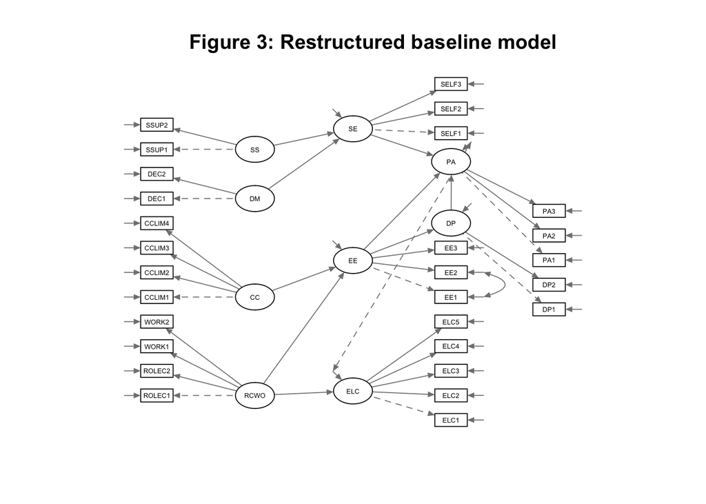

### Exercise 6.2

Let us combine the groups and specify the common baseline (configural) model and draw the graphs.

```
## lavaan 0.6-3 ended normally after 116 iterations
##
##   Optimization method                           NLMINB
##   Number of free parameters                        200
##
##   Number of observations per group
##   calibration                                      602
##   validation                                       601
##
##   Estimator                                         ML      Robust
##   Model Fit Test Statistic                    1622.707    1484.062
##   Degrees of freedom                               668         668
##   P-value (Chi-square)                           0.000       0.000
##   Scaling correction factor                                  1.093
##     for the Satorra-Bentler correction
##
## Chi-square for each group:
##
##   calibration                                  789.858     722.373
##   validation                                   832.848     761.689
```

Fit indices

| Model | Chi.square | Df | p.value | CFI | TLI | RMSEA | SRMR |
| --- | --- | --- | --- | --- | --- | --- | --- |
| Baseline model | 721.5229 | 334 | 0 | 0.951 | 0.944 | 0.046 | 0.053 |
| Configural model | 1484.0618 | 668 | 0 | 0.949 | 0.942 | 0.047 | 0.056 |

The model fit indices in this multigroup configural model are almost as good (but not exactly) as in the calibration group’s baseline model.

### Exercise 6.3

In the invariant model we fix factor means to zero.

```
## lavaan 0.6-3 ended normally after 178 iterations
##
##   Optimization method                           NLMINB
##   Number of free parameters                        200
##   Number of equality constraints                    56
##
##   Number of observations per group
##   calibration                                      602
##   validation                                       601
##
##   Estimator                                         ML      Robust
##   Model Fit Test Statistic                    1682.811    1544.170
##   Degrees of freedom                               724         724
##   P-value (Chi-square)                           0.000       0.000
##   Scaling correction factor                                  1.090
##     for the Satorra-Bentler correction
##
## Chi-square for each group:
##
##   calibration                                  820.825     753.200
##   validation                                   861.986     790.970
```

Fit indices

| Model | Chi.square | Df | p.value | CFI | TLI | RMSEA | SRMR |
| --- | --- | --- | --- | --- | --- | --- | --- |
| Configural model | 1484.062 | 668 | 0 | 0.949 | 0.942 | 0.047 | 0.056 |
| Invariant model | 1544.170 | 724 | 0 | 0.949 | 0.946 | 0.045 | 0.058 |

The model fit indices are quite similar.

```
## Scaled Chi Square Difference Test (method = "satorra.bentler.2001")
##
##           Df   AIC   BIC  Chisq Chisq diff Df diff Pr(>Chisq)
## fit.conf 668 68153 69172 1622.7
## fit.inv  724 68101 68835 1682.8      57.44      56     0.4216
```

The model that was specified step by step with the calibration group seems to have a good fit with the validation group also. It seems that the model is rather well built since the performed changes are not significant.